# Seaborn Tutorial

Di dunia analisis cara terbaik untuk menyampaikan bukti-bukti nyata adalah dengan memvisualisasikan data. Data dapat digambarkan dengan plot tertentu agar lebih mudah untuk dimengerti. Untuk menganalisa sebuah set data menggunakan python, kita dapat memanfaatkan fitur dari library Matplotlib. Demikian halnya dengan Seaborn yang merupakan sebuah library di python untuk merepresentasikan data.

Seaborn dibangun atas dasar library visualisasi Matplotlib. Hal ini dimaksudkan untuk melengkapi fitur yang sudah ada, bukan untuk menggantikan fitur sebelumnya. Diantaranya adalah

> Tema bawaan untuk tampilan grafik Matplotlib Memvisualkan data univariate dan data bivariate Menyesuaikan dan memvisualkan model linear regression Memplotkan data statistik berdasarkan waktu Seaborn dapat dikombinasikan dengan data struktur NumPy dan Panda

Fungsi plot yang berorientasi pada dataset beroperasi pada kerangka data dan array yang berisi seluruh dataset dan secara internal melakukan pemetaan semantik yang diperlukan dan agregasi statistik untuk menghasilkan plot informatif.

Import Libraries

Pandas merupakan sebuah library untuk memanage dataset relational. Seaborn dapat dengan mudah menangani problem dengan DataFrames, dimana secara luas digunakan sebagai struktur data untuk melakukan analisis data. Berikut ini adalah command untuk meng-import pandas.

```python
# Pandas for managing datasets
import pandas as pd
```

Kemudian kita akan mengimport Matplotlib library.

```python
# Matplotlib for additional customization
from matplotlib import pyplot as plt
```

Import Seaborn.

```python
# Seaborn for plotting and styling
import seaborn as sb
```

Import Dataset

Kita telah meng-import library yang diperlukan. Dalam bagian ini, kita akan mengerti bagaimana cara meng-import datasets yang diperlukan. Ketika Seaborn di-install, beberapa datasets penting secara otomatis tersedia di library. Anda dapat menggunakan salah satu datasets untuk pembelajaran. Dengan bantuan fungsi berikut ini anda dapat memuat datasets yang diperlukan.

load_dataset()

Dataframes menyimpan data dalam bentuk grid kotak sehingga data dapat dilihat dengan mudah .Setiap baris dari grid kotak berisi nilai nilai dari sebuah insance, dan setiap kolom grid adalah vektor yang menyimpan data untuk variabel spesifik. Hal ini berarti bahwa baris dari sebuah dataframe tidak perlu untuk mengandung nilai dari tipe data yang sama, mereka dapat bernilai numeric, karakter, logical, dll. Untuk python dataframes datang bersama sama dengan library pandas, dan mereka didefinisikan sebagai struktur data berlabel dua dimensi dengan potensi memiliki berbagai jenis tipe data pada tiap kolom.

```python
# Seaborn for plotting and styling
import seaborn as sb
df = sb.load_dataset('planets')
print (df.head())
```

```
            method  number  orbital_period   mass  distance  year
0  Radial Velocity       1         269.300   7.10     77.40  2006
1  Radial Velocity       1         874.774   2.21     56.95  2008
2  Radial Velocity       1         763.000   2.60     19.84  2011
3  Radial Velocity       1         326.030  19.40    110.62  2007
4  Radial Velocity       1         516.220  10.50    119.47  2009
```

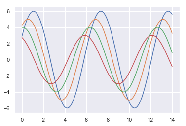

```python
import numpy as np
from matplotlib import pyplot as plt
def sinplot(flip = 1):
   x = np.linspace(0, 14, 100)
   for i in range(1, 5):
      plt.plot(x, np.sin(x + i * .5) * (7 - i) * flip)
sinplot()
plt.show()
```

Hasil default Seaborn.

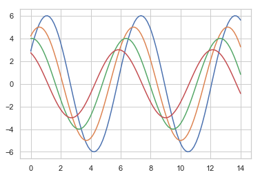

```python
import numpy as np
from matplotlib import pyplot as plt
def sinplot(flip=1):
   x = np.linspace(0, 14, 100)
   for i in range(1, 5):
      plt.plot(x, np.sin(x + i * .5) * (7 - i) * flip)
import seaborn as sb
sb.set_style("whitegrid")
sinplot()
plt.show()
```

Hasil dari dua grafik diatas menunjukkan perbedaan antara Matplotlib dengan Seaborn. Representasi data sama, namun bentuk tampilan berbeda diantara keduanya.

Histogram

Histograms mewakili distribusi data dengan membentuk proporsi di sepanjang jalur data dan kemudian menggambar bar untuk menunjukkan jumlah pengamatan yang jatuh pada setiap proporsi.

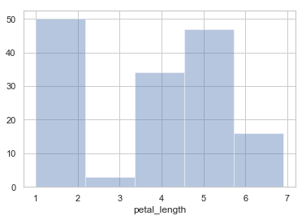

```python
import pandas as pd
import seaborn as sb
from matplotlib import pyplot as plt
df = sb.load_dataset('iris')
sb.distplot(df['petal_length'],kde = False)
plt.show()
```

Kernel Density Estimates

Kernel Density Estimation (KDE) merupakan suatu cara untuk memperkirakan fungsi probabilitas kepadatan dari sebuah variabel acak kontinu. Hal ini digunakan untuk analisis non-parametric. Pengaturan hist flag dengan nilai false dalam distplot akan menghasilkan plot estimasi kepadatan kernel. Di seaborn, kita dapat mem-plot Kernel Density plot dengan menggunakan jointplot().

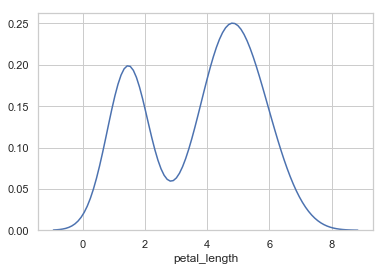

```python
import pandas as pd
import seaborn as sb
from matplotlib import pyplot as plt
df = sb.load_dataset('iris')
sb.distplot(df['petal_length'],hist=False)
plt.show()
```

Distplot ( ) digunakan untuk memvisualisasikan distribusi yang parametric dari sebuah kumpulan data.

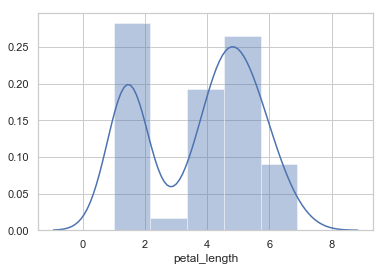

```python
import pandas as pd
import seaborn as sb
from matplotlib import pyplot as plt
df = sb.load_dataset('iris')
sb.distplot(df['petal_length'])
plt.show()
```

Plotting Bivariate Distribution

Distribusi bivariate digunakan untuk menentukan hubungan antara dua variabel. Ini terutama mengatasi hubungan antara dua variabel dan bagaimana satu variabel berperilaku dengan yang lain. Cara terbaik untuk menganalisis distribusi bivariate di seaborn adalah dengan menggunakan fungsi jointplot ( ). Jointplot menciptakan sebuah figur multi-panel yang proyeksikan hubungan bivariate antara dua variabel dan juga distribusi univariate untuk setiap variabel pada poros terpisah.

Scatter Plot

Scatter plot adalah cara yang paling mudah untuk memvisualisasikan distribusi di mana setiap pengamatan diwakili dalam plot dua dimensi melalui sumbu x dan y.

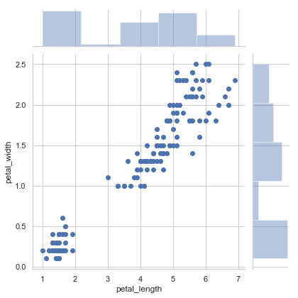

```python
import pandas as pd
import seaborn as sb
from matplotlib import pyplot as plt
df = sb.load_dataset('iris')
sb.jointplot(x = 'petal_length',y = 'petal_width',data = df,kind = 'scatter')
plt.show()
```

Gambar di atas menunjukkan hubungan antara petal_length dan petal_width dalam data iris.Tren pada plot mengatakan bahwa korelasi positif antara variabel.

Hexbin Plot

Binning heksagonal digunakan dalam analisis data bivariate bila data tersebut memiliki kepadatan yang renggang, sebagai contoh bila data tersebut tersebar sangat luas dan sulit untuk dianalisis menggunakan scatterplots. Tambahan parameter seperti ‘kind’ dan nilai ‘hex’ mem-plot hexbin plot.

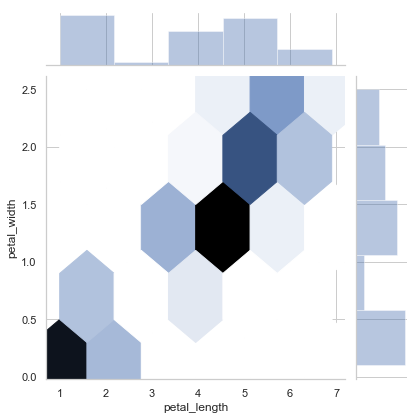

```python
import pandas as pd
import seaborn as sb
from matplotlib import pyplot as plt
df = sb.load_dataset('iris')
sb.jointplot(x = 'petal_length',y = 'petal_width',data = df,kind = 'hex')
plt.show()
```

Di seaborn, kita dapat mem-plot Kernel Density plot dengan menggunakan jointplot().

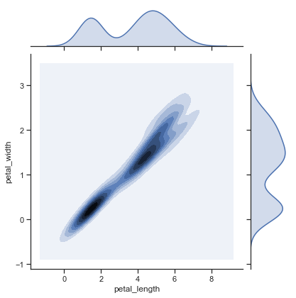

```python
import pandas as pd
import seaborn as sb
from matplotlib import pyplot as plt
df = sb.load_dataset('iris')
sb.jointplot(x = 'petal_length',y = 'petal_width',data = df,kind = 'kde')
plt.show()
```

Visualizing Pairwise Relationship

Datasets dalam penelitian yang bersifat real-time memiliki banyak variable. Dalam kasus ini, hubungan ntara masing-masing dan setiap variabel harus dianalisis. Distribusi bivariate untuk kombinasi (n, 2) ini merupakan salah satu kombinasi yang sangat kompleks dan menghabiskan waktu. Untuk mem-plot beberapa penyebaran dalam sebuah kumpulan data pairwise bivariate, anda dapat menggunakan fungsi pairplot ( ). Hal ini menunjukkan hubungan untuk kombinasi yang berdampingan dari variabel (n, 2) dalam sebuah dataframe sebagai sebuah matrix plot dan plot diagonal adalah plot univariate.

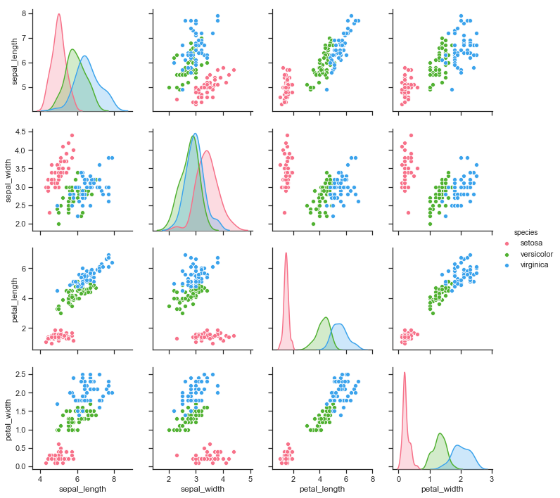

```python
import pandas as pd
import seaborn as sb
from matplotlib import pyplot as plt
df = sb.load_dataset('iris')
sb.set_style("ticks")
sb.pairplot(df,hue = 'species',diag_kind = "kde",kind = "scatter",palette = "husl")
plt.show()
```